# Risk Factor Analysis

## Outcome Variable

**Outcome Variable:** pers_wast

## Predictor Variables

**Intervention Variable:** hhwealth_quart

**Adjustment Set:**

- arm
- sex
- W_mage
- meducyrs
- feducyrs
- W_gagebrth
- W_birthwt
- W_birthlen
- W_nchldlt5
- W_parity
- delta_W_mage
- delta_meducyrs
- delta_feducyrs
- delta_W_gagebrth
- delta_W_birthwt
- delta_W_birthlen
- delta_W_nchldlt5
- delta_W_parity

## Stratifying Variables

The analysis was stratified on these variable(s):

- agecat
- studyid
- country

## Data Summary

| agecat | studyid | country | hhwealth_quart | pers_wast | n_cell | n |
| --- | --- | --- | --- | --- | --- | --- |
| 0-24 months | CMC-V-BCS-2002 | INDIA | Wealth Q4 | 0 | 93 | 373 |
| 0-24 months | CMC-V-BCS-2002 | INDIA | Wealth Q4 | 1 | 3 | 373 |
| 0-24 months | CMC-V-BCS-2002 | INDIA | Wealth Q1 | 0 | 83 | 373 |
| 0-24 months | CMC-V-BCS-2002 | INDIA | Wealth Q1 | 1 | 8 | 373 |
| 0-24 months | CMC-V-BCS-2002 | INDIA | Wealth Q2 | 0 | 89 | 373 |
| 0-24 months | CMC-V-BCS-2002 | INDIA | Wealth Q2 | 1 | 6 | 373 |
| 0-24 months | CMC-V-BCS-2002 | INDIA | Wealth Q3 | 0 | 85 | 373 |
| 0-24 months | CMC-V-BCS-2002 | INDIA | Wealth Q3 | 1 | 6 | 373 |
| 0-24 months | COHORTS | GUATEMALA | Wealth Q4 | 0 | 375 | 1023 |
| 0-24 months | COHORTS | GUATEMALA | Wealth Q4 | 1 | 9 | 1023 |
| 0-24 months | COHORTS | GUATEMALA | Wealth Q1 | 0 | 199 | 1023 |
| 0-24 months | COHORTS | GUATEMALA | Wealth Q1 | 1 | 4 | 1023 |
| 0-24 months | COHORTS | GUATEMALA | Wealth Q2 | 0 | 197 | 1023 |
| 0-24 months | COHORTS | GUATEMALA | Wealth Q2 | 1 | 11 | 1023 |
| 0-24 months | COHORTS | GUATEMALA | Wealth Q3 | 0 | 217 | 1023 |
| 0-24 months | COHORTS | GUATEMALA | Wealth Q3 | 1 | 11 | 1023 |
| 0-24 months | COHORTS | PHILIPPINES | Wealth Q4 | 0 | 754 | 2811 |
| 0-24 months | COHORTS | PHILIPPINES | Wealth Q4 | 1 | 19 | 2811 |
| 0-24 months | COHORTS | PHILIPPINES | Wealth Q1 | 0 | 556 | 2811 |
| 0-24 months | COHORTS | PHILIPPINES | Wealth Q1 | 1 | 48 | 2811 |
| 0-24 months | COHORTS | PHILIPPINES | Wealth Q2 | 0 | 476 | 2811 |
| 0-24 months | COHORTS | PHILIPPINES | Wealth Q2 | 1 | 27 | 2811 |
| 0-24 months | COHORTS | PHILIPPINES | Wealth Q3 | 0 | 881 | 2811 |
| 0-24 months | COHORTS | PHILIPPINES | Wealth Q3 | 1 | 50 | 2811 |
| 0-24 months | CONTENT | PERU | Wealth Q4 | 0 | 52 | 215 |
| 0-24 months | CONTENT | PERU | Wealth Q4 | 1 | 0 | 215 |
| 0-24 months | CONTENT | PERU | Wealth Q1 | 0 | 59 | 215 |
| 0-24 months | CONTENT | PERU | Wealth Q1 | 1 | 0 | 215 |
| 0-24 months | CONTENT | PERU | Wealth Q2 | 0 | 52 | 215 |
| 0-24 months | CONTENT | PERU | Wealth Q2 | 1 | 0 | 215 |

[output cut: 114 more lines]

The following strata were considered:

- agecat: 0-24 months, studyid: CMC-V-BCS-2002, country: INDIA
- agecat: 0-24 months, studyid: COHORTS, country: GUATEMALA
- agecat: 0-24 months, studyid: COHORTS, country: PHILIPPINES
- agecat: 0-24 months, studyid: CONTENT, country: PERU
- agecat: 0-24 months, studyid: GMS-Nepal, country: NEPAL
- agecat: 0-24 months, studyid: IRC, country: INDIA
- agecat: 0-24 months, studyid: JiVitA-3, country: BANGLADESH
- agecat: 0-24 months, studyid: JiVitA-4, country: BANGLADESH
- agecat: 0-24 months, studyid: LCNI-5, country: MALAWI
- agecat: 0-24 months, studyid: MAL-ED, country: BANGLADESH
- agecat: 0-24 months, studyid: MAL-ED, country: BRAZIL
- agecat: 0-24 months, studyid: MAL-ED, country: INDIA
- agecat: 0-24 months, studyid: MAL-ED, country: NEPAL
- agecat: 0-24 months, studyid: MAL-ED, country: PERU
- agecat: 0-24 months, studyid: MAL-ED, country: SOUTH AFRICA
- agecat: 0-24 months, studyid: MAL-ED, country: TANZANIA, UNITED REPUBLIC OF
- agecat: 0-24 months, studyid: PROVIDE, country: BANGLADESH
- agecat: 0-24 months, studyid: TanzaniaChild2, country: TANZANIA, UNITED REPUBLIC OF

### Dropped Strata

Some strata were dropped due to rare outcomes:

- agecat: 0-24 months, studyid: CMC-V-BCS-2002, country: INDIA
- agecat: 0-24 months, studyid: COHORTS, country: GUATEMALA
- agecat: 0-24 months, studyid: CONTENT, country: PERU
- agecat: 0-24 months, studyid: LCNI-5, country: MALAWI
- agecat: 0-24 months, studyid: MAL-ED, country: BANGLADESH
- agecat: 0-24 months, studyid: MAL-ED, country: BRAZIL
- agecat: 0-24 months, studyid: MAL-ED, country: INDIA
- agecat: 0-24 months, studyid: MAL-ED, country: NEPAL
- agecat: 0-24 months, studyid: MAL-ED, country: PERU
- agecat: 0-24 months, studyid: MAL-ED, country: SOUTH AFRICA
- agecat: 0-24 months, studyid: MAL-ED, country: TANZANIA, UNITED REPUBLIC OF
- agecat: 0-24 months, studyid: PROVIDE, country: BANGLADESH

## Methods Detail

We're interested in the causal parameters $E[Y_a]$ for all values of $a \in \mathcal{A}$. These parameters represent the mean outcome if, possibly contrary to fact, we intervened to set all units to have $A=a$. Under the randomization and positivity assumptions, these are identified by the statistical parameters $\psi_a=E_W[E_{Y|A,W}(Y|A=a,W)]$. In addition, we're interested in the mean of $Y$, $E[Y]$ under no intervention (the observed mean). We will estimate these parameters by using SuperLearner to fit the relevant likelihood factors -- $E_{Y|A,W}(Y|A=a,W)$ and $p(A=a|W)$, and then updating our likelihood fit using a joint TMLE.

For unadjusted analyses ($W=\{\}$), initial likelihoods were estimated using Lrnr_glm to estimate the simple $E(Y|A)$ and Lrnr_mean to estimate $p(A)$. For adjusted analyses, a small library containing Lrnr_glmnet, Lrnr_xgboost, and Lrnr_mean was used.

Having estimated these parameters, we will then use the delta method to estimate relative risks and attributable risks relative to a prespecified baseline level of $A$.

# Results Detail

## Results Plots

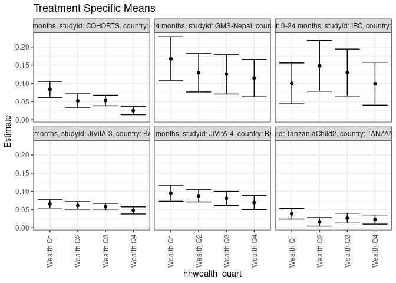

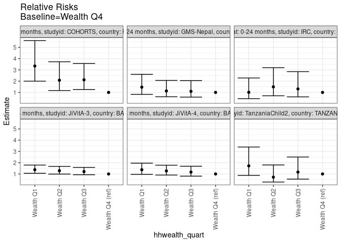

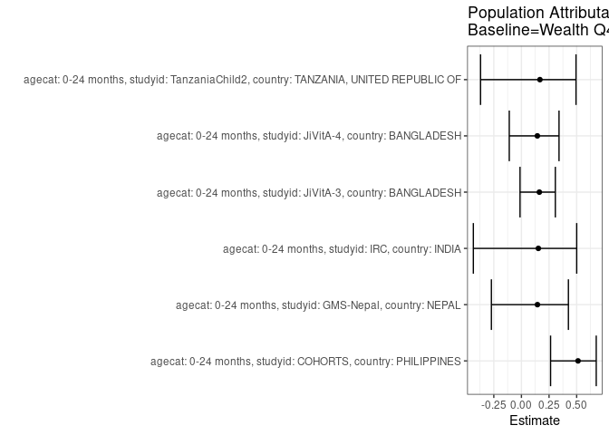

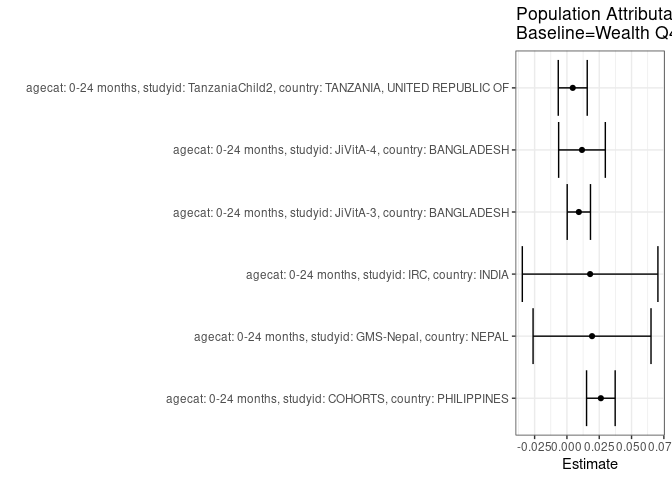

## Results Table

### Parameter: TSM

| agecat | studyid | country | intervention_level | baseline_level | estimate | ci_lower | ci_upper |
| --- | --- | --- | --- | --- | --- | --- | --- |
| 0-24 months | COHORTS | PHILIPPINES | Wealth Q4 | NA | 0.0249742 | 0.0139039 | 0.0360444 |
| 0-24 months | COHORTS | PHILIPPINES | Wealth Q1 | NA | 0.0835222 | 0.0615107 | 0.1055336 |
| 0-24 months | COHORTS | PHILIPPINES | Wealth Q2 | NA | 0.0520516 | 0.0325953 | 0.0715079 |
| 0-24 months | COHORTS | PHILIPPINES | Wealth Q3 | NA | 0.0529435 | 0.0384511 | 0.0674358 |
| 0-24 months | GMS-Nepal | NEPAL | Wealth Q4 | NA | 0.1145705 | 0.0631561 | 0.1659849 |
| 0-24 months | GMS-Nepal | NEPAL | Wealth Q1 | NA | 0.1679246 | 0.1072611 | 0.2285881 |
| 0-24 months | GMS-Nepal | NEPAL | Wealth Q2 | NA | 0.1293195 | 0.0765931 | 0.1820459 |
| 0-24 months | GMS-Nepal | NEPAL | Wealth Q3 | NA | 0.1254439 | 0.0707717 | 0.1801161 |
| 0-24 months | IRC | INDIA | Wealth Q4 | NA | 0.0991347 | 0.0401997 | 0.1580698 |
| 0-24 months | IRC | INDIA | Wealth Q1 | NA | 0.1000109 | 0.0437827 | 0.1562392 |
| 0-24 months | IRC | INDIA | Wealth Q2 | NA | 0.1483184 | 0.0785420 | 0.2180948 |
| 0-24 months | IRC | INDIA | Wealth Q3 | NA | 0.1300360 | 0.0654824 | 0.1945897 |
| 0-24 months | JiVitA-3 | BANGLADESH | Wealth Q4 | NA | 0.0475732 | 0.0377287 | 0.0574178 |
| 0-24 months | JiVitA-3 | BANGLADESH | Wealth Q1 | NA | 0.0655221 | 0.0543398 | 0.0767043 |
| 0-24 months | JiVitA-3 | BANGLADESH | Wealth Q2 | NA | 0.0613084 | 0.0509723 | 0.0716445 |
| 0-24 months | JiVitA-3 | BANGLADESH | Wealth Q3 | NA | 0.0577212 | 0.0484240 | 0.0670183 |
| 0-24 months | JiVitA-4 | BANGLADESH | Wealth Q4 | NA | 0.0690541 | 0.0499249 | 0.0881833 |
| 0-24 months | JiVitA-4 | BANGLADESH | Wealth Q1 | NA | 0.0948172 | 0.0725381 | 0.1170963 |
| 0-24 months | JiVitA-4 | BANGLADESH | Wealth Q2 | NA | 0.0876044 | 0.0707999 | 0.1044089 |
| 0-24 months | JiVitA-4 | BANGLADESH | Wealth Q3 | NA | 0.0806222 | 0.0613528 | 0.0998916 |
| 0-24 months | TanzaniaChild2 | TANZANIA, UNITED REPUBLIC OF | Wealth Q4 | NA | 0.0223881 | 0.0098607 | 0.0349154 |
| 0-24 months | TanzaniaChild2 | TANZANIA, UNITED REPUBLIC OF | Wealth Q1 | NA | 0.0385208 | 0.0237112 | 0.0533304 |
| 0-24 months | TanzaniaChild2 | TANZANIA, UNITED REPUBLIC OF | Wealth Q2 | NA | 0.0160183 | 0.0042447 | 0.0277919 |
| 0-24 months | TanzaniaChild2 | TANZANIA, UNITED REPUBLIC OF | Wealth Q3 | NA | 0.0261682 | 0.0126381 | 0.0396983 |

### Parameter: E(Y)

| agecat | studyid | country | intervention_level | baseline_level | estimate | ci_lower | ci_upper |
| --- | --- | --- | --- | --- | --- | --- | --- |
| 0-24 months | COHORTS | PHILIPPINES | NA | NA | 0.0512273 | 0.0430760 | 0.0593786 |
| 0-24 months | GMS-Nepal | NEPAL | NA | NA | 0.1340034 | 0.1066544 | 0.1613523 |
| 0-24 months | IRC | INDIA | NA | NA | 0.1170732 | 0.0859146 | 0.1482317 |
| 0-24 months | JiVitA-3 | BANGLADESH | NA | NA | 0.0567865 | 0.0526703 | 0.0609027 |
| 0-24 months | JiVitA-4 | BANGLADESH | NA | NA | 0.0806971 | 0.0720842 | 0.0893100 |
| 0-24 months | TanzaniaChild2 | TANZANIA, UNITED REPUBLIC OF | NA | NA | 0.0268892 | 0.0200612 | 0.0337172 |

### Parameter: RR

| agecat | studyid | country | intervention_level | baseline_level | estimate | ci_lower | ci_upper |
| --- | --- | --- | --- | --- | --- | --- | --- |
| 0-24 months | COHORTS | PHILIPPINES | Wealth Q4 | Wealth Q4 | 1.0000000 | 1.0000000 | 1.000000 |
| 0-24 months | COHORTS | PHILIPPINES | Wealth Q1 | Wealth Q4 | 3.3443432 | 1.9968135 | 5.601240 |
| 0-24 months | COHORTS | PHILIPPINES | Wealth Q2 | Wealth Q4 | 2.0842183 | 1.1670858 | 3.722062 |
| 0-24 months | COHORTS | PHILIPPINES | Wealth Q3 | Wealth Q4 | 2.1199301 | 1.2589787 | 3.569642 |
| 0-24 months | GMS-Nepal | NEPAL | Wealth Q4 | Wealth Q4 | 1.0000000 | 1.0000000 | 1.000000 |
| 0-24 months | GMS-Nepal | NEPAL | Wealth Q1 | Wealth Q4 | 1.4656882 | 0.8238535 | 2.607553 |
| 0-24 months | GMS-Nepal | NEPAL | Wealth Q2 | Wealth Q4 | 1.1287331 | 0.6154823 | 2.069984 |
| 0-24 months | GMS-Nepal | NEPAL | Wealth Q3 | Wealth Q4 | 1.0949056 | 0.5855703 | 2.047266 |
| 0-24 months | IRC | INDIA | Wealth Q4 | Wealth Q4 | 1.0000000 | 1.0000000 | 1.000000 |
| 0-24 months | IRC | INDIA | Wealth Q1 | Wealth Q4 | 1.0088386 | 0.4457057 | 2.283469 |
| 0-24 months | IRC | INDIA | Wealth Q2 | Wealth Q4 | 1.4961296 | 0.7003185 | 3.196265 |
| 0-24 months | IRC | INDIA | Wealth Q3 | Wealth Q4 | 1.3117100 | 0.6044819 | 2.846377 |
| 0-24 months | JiVitA-3 | BANGLADESH | Wealth Q4 | Wealth Q4 | 1.0000000 | 1.0000000 | 1.000000 |
| 0-24 months | JiVitA-3 | BANGLADESH | Wealth Q1 | Wealth Q4 | 1.3772884 | 1.0587505 | 1.791662 |
| 0-24 months | JiVitA-3 | BANGLADESH | Wealth Q2 | Wealth Q4 | 1.2887162 | 0.9924495 | 1.673425 |
| 0-24 months | JiVitA-3 | BANGLADESH | Wealth Q3 | Wealth Q4 | 1.2133116 | 0.9293369 | 1.584059 |
| 0-24 months | JiVitA-4 | BANGLADESH | Wealth Q4 | Wealth Q4 | 1.0000000 | 1.0000000 | 1.000000 |
| 0-24 months | JiVitA-4 | BANGLADESH | Wealth Q1 | Wealth Q4 | 1.3730849 | 0.9628732 | 1.958059 |
| 0-24 months | JiVitA-4 | BANGLADESH | Wealth Q2 | Wealth Q4 | 1.2686343 | 0.9063043 | 1.775820 |
| 0-24 months | JiVitA-4 | BANGLADESH | Wealth Q3 | Wealth Q4 | 1.1675217 | 0.8091544 | 1.684607 |
| 0-24 months | TanzaniaChild2 | TANZANIA, UNITED REPUBLIC OF | Wealth Q4 | Wealth Q4 | 1.0000000 | 1.0000000 | 1.000000 |
| 0-24 months | TanzaniaChild2 | TANZANIA, UNITED REPUBLIC OF | Wealth Q1 | Wealth Q4 | 1.7205958 | 0.8726409 | 3.392518 |
| 0-24 months | TanzaniaChild2 | TANZANIA, UNITED REPUBLIC OF | Wealth Q2 | Wealth Q4 | 0.7154844 | 0.2840630 | 1.802128 |
| 0-24 months | TanzaniaChild2 | TANZANIA, UNITED REPUBLIC OF | Wealth Q3 | Wealth Q4 | 1.1688474 | 0.5456139 | 2.503976 |

### Parameter: PAR

| agecat | studyid | country | intervention_level | baseline_level | estimate | ci_lower | ci_upper |
| --- | --- | --- | --- | --- | --- | --- | --- |
| 0-24 months | COHORTS | PHILIPPINES | Wealth Q4 | NA | 0.0262532 | 0.0151851 | 0.0373213 |
| 0-24 months | GMS-Nepal | NEPAL | Wealth Q4 | NA | 0.0194329 | -0.0261932 | 0.0650589 |
| 0-24 months | IRC | INDIA | Wealth Q4 | NA | 0.0179384 | -0.0345198 | 0.0703967 |
| 0-24 months | JiVitA-3 | BANGLADESH | Wealth Q4 | NA | 0.0092133 | 0.0002043 | 0.0182222 |
| 0-24 months | JiVitA-4 | BANGLADESH | Wealth Q4 | NA | 0.0116430 | -0.0064177 | 0.0297037 |
| 0-24 months | TanzaniaChild2 | TANZANIA, UNITED REPUBLIC OF | Wealth Q4 | NA | 0.0045011 | -0.0067043 | 0.0157066 |

### Parameter: PAF

| agecat | studyid | country | intervention_level | baseline_level | estimate | ci_lower | ci_upper |
| --- | --- | --- | --- | --- | --- | --- | --- |
| 0-24 months | COHORTS | PHILIPPINES | Wealth Q4 | NA | 0.5124835 | 0.2638504 | 0.6771412 |
| 0-24 months | GMS-Nepal | NEPAL | Wealth Q4 | NA | 0.1450177 | -0.2718602 | 0.4252554 |
| 0-24 months | IRC | INDIA | Wealth Q4 | NA | 0.1532242 | -0.4352759 | 0.5004241 |
| 0-24 months | JiVitA-3 | BANGLADESH | Wealth Q4 | NA | 0.1622443 | -0.0127165 | 0.3069783 |
| 0-24 months | JiVitA-4 | BANGLADESH | Wealth Q4 | NA | 0.1442799 | -0.1099947 | 0.3403059 |
| 0-24 months | TanzaniaChild2 | TANZANIA, UNITED REPUBLIC OF | Wealth Q4 | NA | 0.1673958 | -0.3700147 | 0.4939983 |